# Sanket Khamkar_Midterm

Sanket

2024-11-04

• Correctly import the data.

Plot and Inference • Show a time series plot. • Please summaries your observations of the times series plot

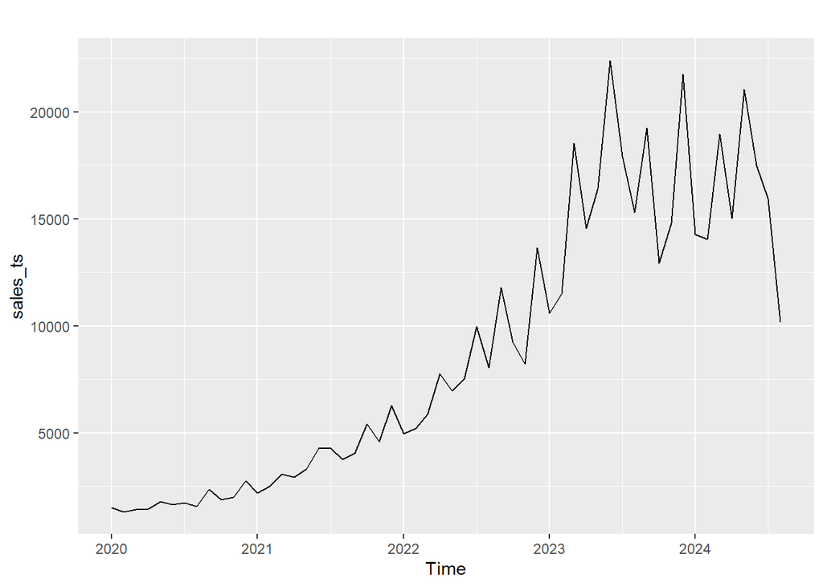

```r
autoplot(sales_ts)
```

• The time series plot shows years on X-axis and sales on Y-axis

• The plot shows there was a increasing trend from years 2020 to 2024. This suggests there is a growth in sales over time, maybe because this growth suggests the product’s popularity or necessity is rising, which could be due to factors like aging populations, seasonal illnesses, or heightened awareness because of covid.

• There are noticeable recurring peaks and dips, especially from 2023 onwards, indicating possible seasonality. For healthcare products, this could correspond to seasonal illness cycles (e.g., flu season), promotional campaigns, or insurance cycles that affect when customers make purchases.

• Toward the end of the series in 2024, there is a harsh downward trend. This could indicate a temporary drop in sales or the start of a potential decline, which may need further analysis to determine if it’s a seasonal effect or a more prolonged issue.

Central Tendency • What are the min, max, mean, median, 1st, and 3rd Quartile values of the times series?  
• Show the box plot.  
• Can you summarize your observation about the time series from the summary stats and box plot?

```r
summary(sales_ts)
```

```
##    Min. 1st Qu.  Median    Mean 3rd Qu.    Max.
##    1322    2892    7246    8753   14346   22397
```

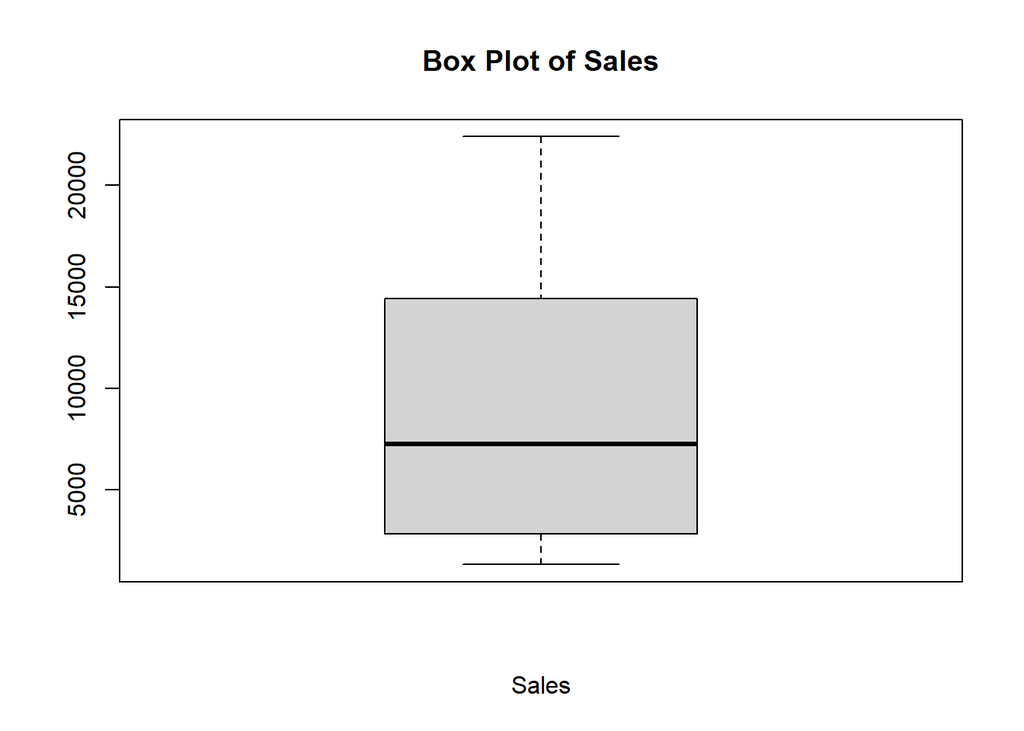

```r
boxplot(sales_ts, main="Box Plot of Sales", xlab="Sales")
```

The mean (8,753) is greater than the median (7,246), indicating data is right-skewed. This suggests that there are some higher sales figures pulling the average up. This could suggest that while most of the time demand is stable, there are occasional big order days.

The difference between the 1st quartile (2,892) and the 3rd quartile (14,346) is large, indicating high variability in sales. This wide range aligns with the observed volatility and fluctuations in the time series plot.

The box plot does not show any outliers, meaning most sales values fall within the expected range. The high sales variability appears to be part of the natural sales fluctuations rather than anomalies.

The box plot and summary show that sales have some noticeable peaks. There’s a high maximum sales number, much higher than the “usual” sales range. This could mean there are periods when demand for this drug spikes—maybe during flu season or other health events when more people need it.

The maximum value (22,397) is considerably higher than the third quartile. Hence, here’s a high maximum sales number, much higher than the “usual” sales range. This could mean there are periods when demand for this drug spikes—maybe during flu season or other health events when more people need it.

#### Decomposition

• Plot the decomposition of the time series.

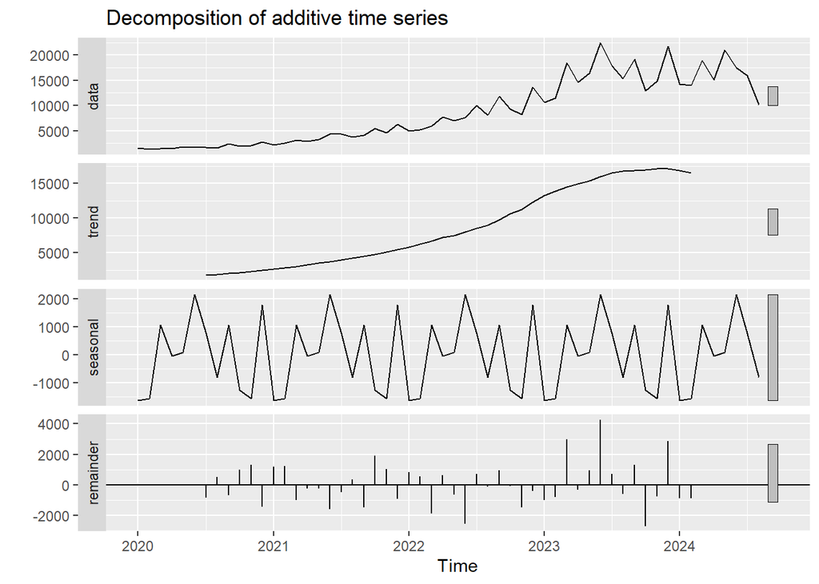

```r
decomp <- decompose(sales_ts, type="additive")
autoplot(decomp)
```

```r
seasonal_component <- decomp$seasonal

# Calculate average seasonal indices for each month
monthly_indices <- tapply(seasonal_component, cycle(seasonal_component), mean)

# Display the monthly indices
print(round(monthly_indices, 2))
```

```
##        1        2        3        4        5        6        7        8
## -1637.61 -1562.74  1068.73   -57.47    87.83  2154.72   753.36  -814.83
##        9       10       11       12
##  1059.15 -1259.71 -1565.33  1773.90
```

• Is the time series seasonal? Yes, this time series is seasonal. We can tell because there’s a clear, repeating pattern in the seasonal component of the decomposition.

• Is the decomposition additive or multiplicative?  
This decomposition is addictive as each month’s seasonal effect is a fixed amount added to or subtracted from the trend, showing consistent seasonal ups and downs across years.

• Can you think of the reason behind the high and low values in those months? The high sales in June could be because people are more active in the summer, leading to higher demand for things like allergy meds, skincare, or pain relief for outdoor activities. It’s also a time when people feel comfortable with their insurance benefits mid-year and might spend more on healthcare.

• Show the plot for time series adjusted for seasonality. Overlay this with the line for actuals? Does seasonality have big fluctuations in the value of time series?

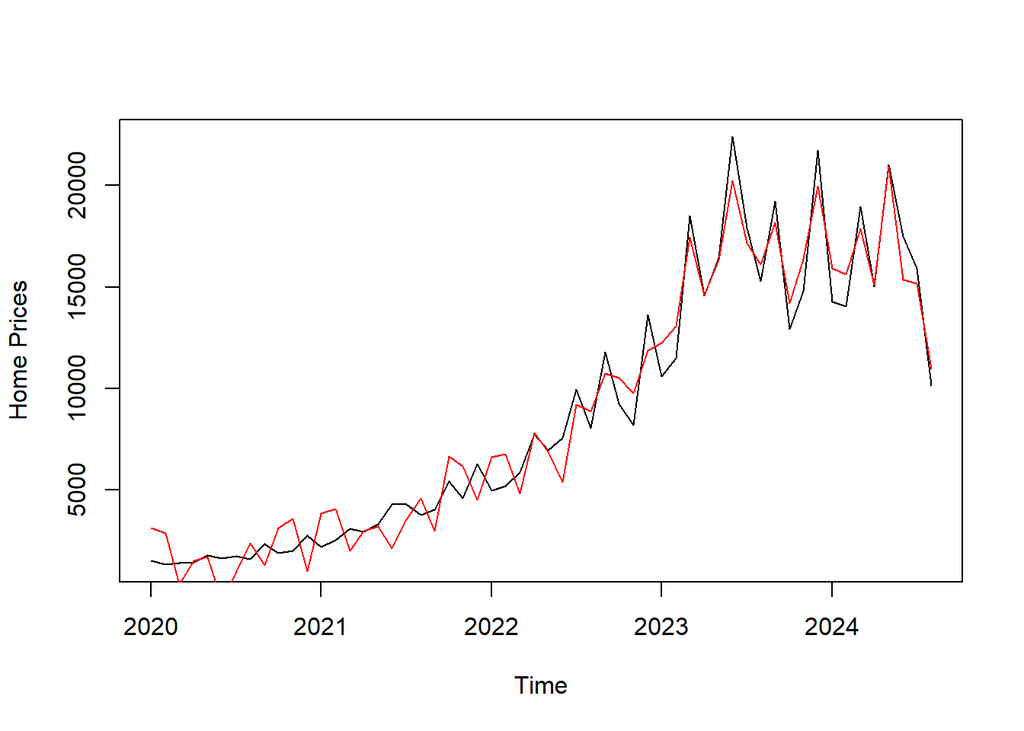

```r
SATS <- seasadj(decomp)
plot(sales_ts, ylab="Home Prices")
lines(SATS, col="red")
```

In simple terms, the plot shows that seasonality creates big swings in sales, and without accounting for it, we might misinterpret the true underlying trend.

###### Naïve Method

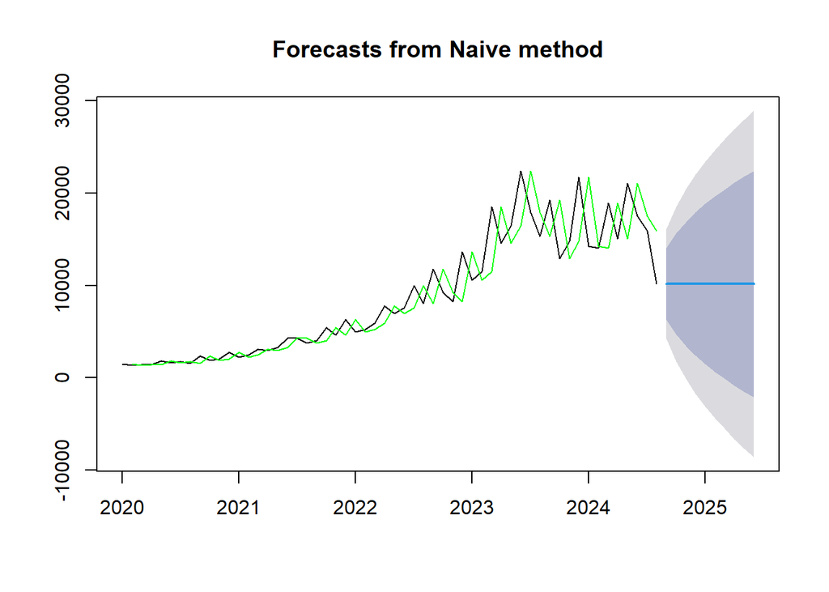

```r
naive_fc = naive(sales_ts)
plot(naive_fc)
lines(naive_fc$fitted, col="green")
```

```r
accuracy(naive_fc)
```

```
##                   ME    RMSE      MAE       MPE     MAPE      MASE      ACF1
## Training set 157.275 3029.52 2104.495 0.6371928 20.12969 0.4670533 -0.433312
```

Perform Residual Analysis for this technique.

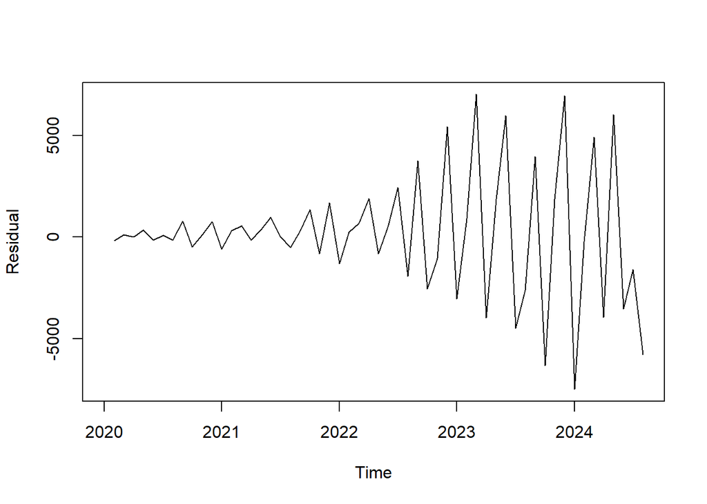

```r
naive_residual <- naive_fc$residuals
naive_fitted <- naive_fc$fitted
plot(naive_residual, ylab="Residual")
```

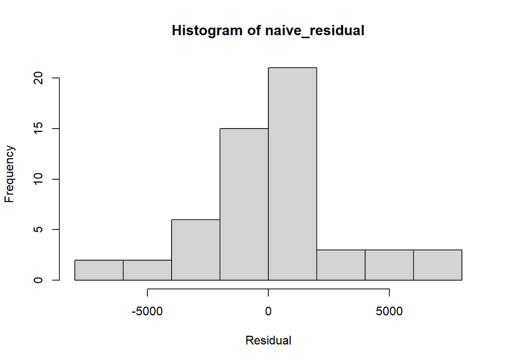

```r
hist(naive_residual, xlab="Residual")
```

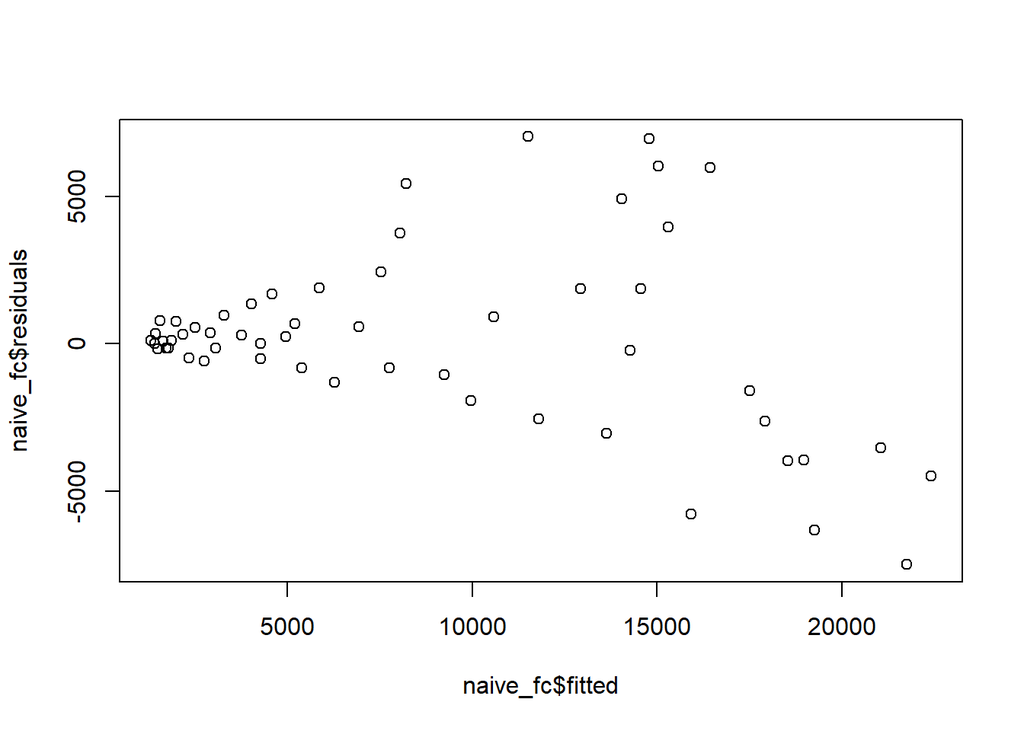

```r
plot.ts(naive_fc$fitted,naive_fc$residuals,xy.labels = FALSE,xy.lines = FALSE)
```

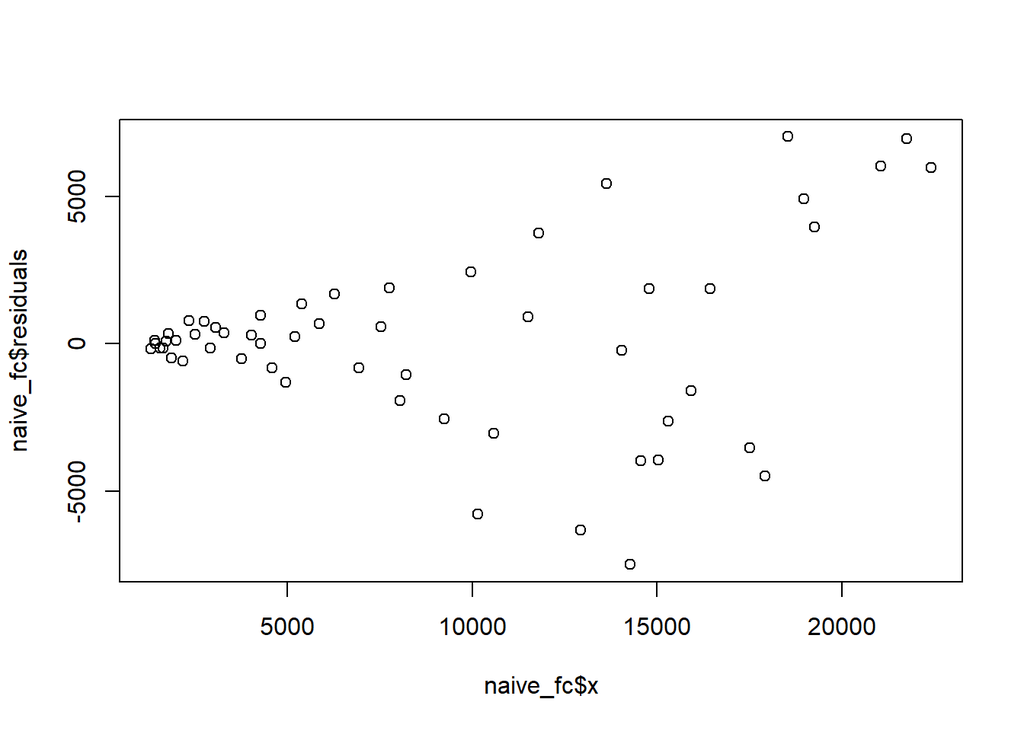

```r
plot.ts(naive_fc$x,naive_fc$residuals,xy.labels = FALSE,xy.lines = FALSE)
```

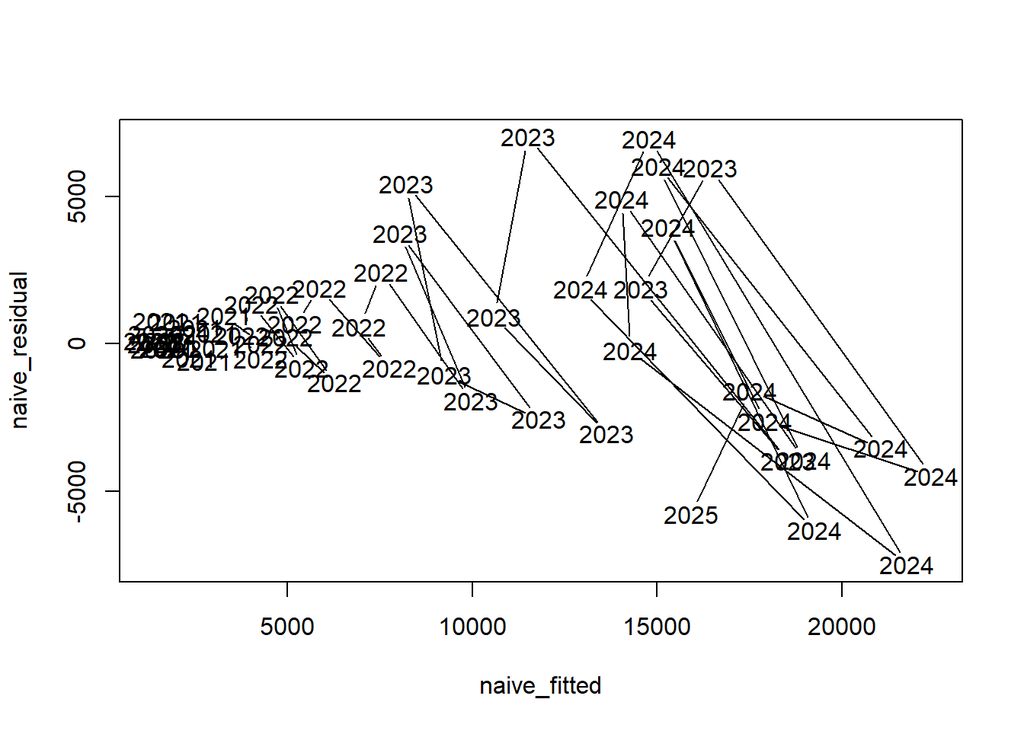

```r
plot(naive_fitted, naive_residual)
```

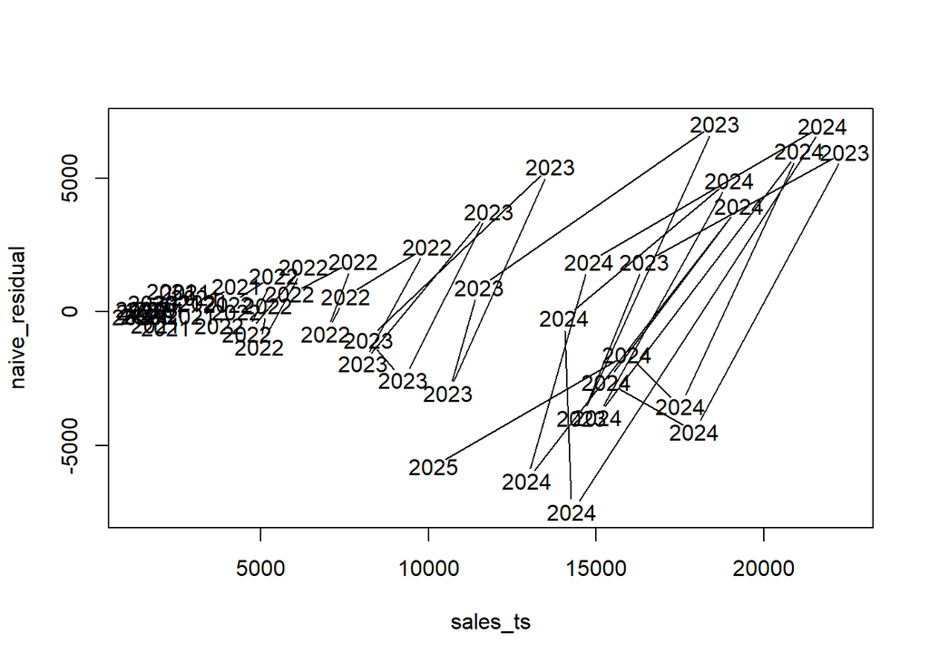

```r
plot(sales_ts, naive_residual)
```

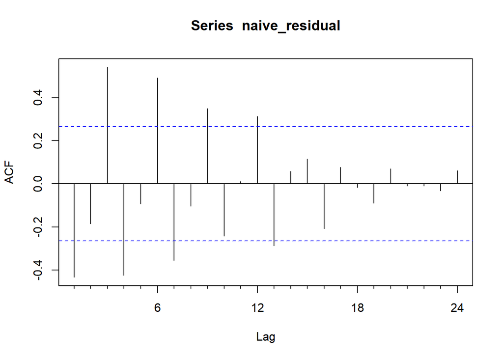

```r
Acf(naive_residual)
```

```r
accuracy(naive_fc)
```

```
##                   ME    RMSE      MAE       MPE     MAPE      MASE      ACF1
## Training set 157.275 3029.52 2104.495 0.6371928 20.12969 0.4670533 -0.433312
```

```r
naive_forecast <- forecast(naive_fc,20)
naive_forecast
```

```
##          Point Forecast      Lo 80    Hi 80      Lo 95    Hi 95
## Sep 2024       10151.93  6269.4469 14034.42  4214.1830 16089.68
## Oct 2024       10151.93  4661.2686 15642.60  1754.6864 18549.18
## Nov 2024       10151.93  3427.2699 16876.60  -132.5517 20436.42
## Dec 2024       10151.93  2386.9609 17916.91 -1723.5671 22027.43
## Jan 2025       10151.93  1470.4302 18833.44 -3125.2797 23429.15
## Feb 2025       10151.93   641.8232 19662.04 -4392.5248 24696.39
## Mar 2025       10151.93  -120.1596 20424.03 -5557.8769 25861.74
## Apr 2025       10151.93  -829.3959 21133.26 -6642.5603 26946.43
## May 2025       10151.93 -1495.5252 21799.39 -7661.3171 27965.18
## Jun 2025       10151.93 -2125.5659 22429.43 -8624.8813 28928.75
```

```r
accuracy(naive_forecast)
```

```
##                   ME    RMSE      MAE       MPE     MAPE      MASE      ACF1
## Training set 157.275 3029.52 2104.495 0.6371928 20.12969 0.4670533 -0.433312
```

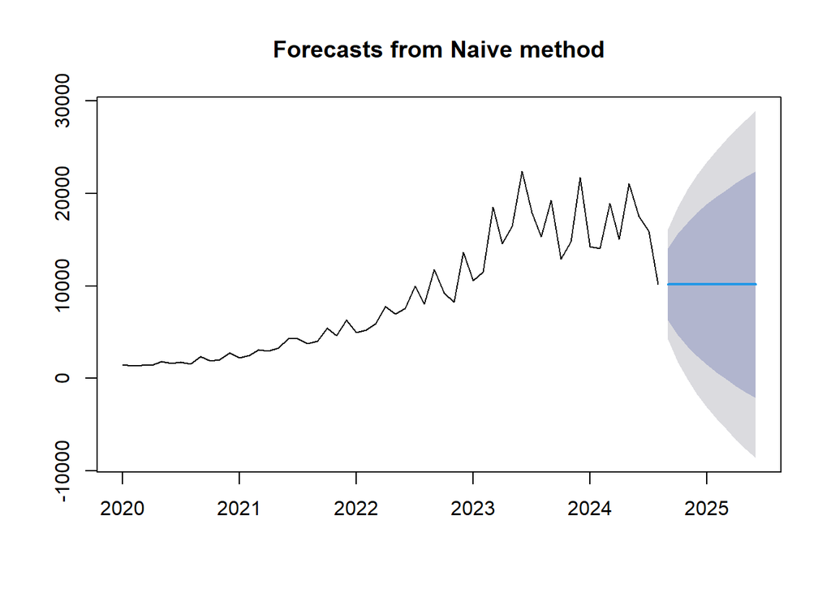

```r
plot(naive_forecast)
```

o Do a plot of residuals. What does the plot indicate? The residual plot shows the differences between the actual values and the predicted values over time. Ideally, the residuals should fluctuate randomly around zero without any clear pattern. If we see this randomness, it means the model is doing a good job capturing the trend and seasonality. Any visible pattern, however, could indicate that the model is missing some information.

o Do a Histogram plot of residuals. What does the plot indicate? What does the plot indicate? The histogram of residuals shows how the errors are distributed. If the residuals are roughly centered around zero and follow a bell-shaped (normal) curve, it indicates that the model’s errors are fairly random and normally distributed. This is a good sign, as it suggests the model doesn’t systematically over- or under-predict.

o Do a plot of fitted values vs. residuals. What does the plot indicate? This scatter plot shows the fitted values (the model’s predictions) on the x-axis and the residuals on the y-axis. Ideally, we’d like to see no clear pattern in this plot—just random scatter around zero. If there’s a visible pattern (like a curve), it suggests the model might not be capturing some aspects of the data correctly, and adjustments could improve the model.

o Do a plot of actual values vs. residuals. What does the plot indicate? What does the plot indicate? Similar to the previous plot, this one compares the actual values with the residuals. Random scatter around zero means the model is doing a consistent job across different levels of sales. If residuals cluster in a pattern, it suggests inconsistencies in the model’s accuracy across different sales levels, indicating potential improvement areas.

o Do an ACF plot of the residuals? What does this plot indicate? What does this plot indicate? The ACF (Autocorrelation Function) plot shows if residuals are correlated over time. Ideally, residuals should be independent, with values close to zero for all lags. If we see significant peaks, it means that residuals are correlated, suggesting the model could be improved to account for this autocorrelation.

• Print the five measures of accuracy for this forecasting technique

```
              ME    RMSE      MAE       MPE     MAPE      MASE
```

Training set 157.275 3029.52 2104.495 0.6371928 20.12969 0.4670533

Forecast  
o Time series value for next year. Show table and plot

The forecast for the next year provides monthly predictions with confidence intervals. The forecast table shows a “Point Forecast” as the expected sales value for each month, along with intervals (Lo 80, Hi 80, Lo 95, Hi 95) that give a range within which future values are likely to fall, with 80% and 95% confidence levels.

Summarize this forecasting technique o How good is the accuracy? Generally, lower values across these metrics indicate a more accurate model. Based on the accuracy metrics, if RMSE and MAE values are relatively low compared to the sales levels, the model provides a good level of accuracy for planning purposes.

o What does it predict the time series value will be in one year? The forecast gives a stable prediction around 10,151.93 for each month of the next year, with confidence intervals expanding over time, indicating increasing uncertainty.

o Other observation The residual and ACF plots provide insight into the model’s fit. If residuals are random and there’s no autocorrelation, it indicates that the model is well-suited for this data. However, any visible patterns in the residuals could mean that there’s room for further refinement of the model.

7. Forecast for Next Year The forecast for the next year provides monthly predictions with confidence intervals. The forecast table shows a “Point Forecast” as the expected sales value for each month, along with intervals (Lo 80, Hi 80, Lo 95, Hi 95) that give a range within which future values are likely to fall, with 80% and 95% confidence levels.
8. Summary of Forecasting Technique How good is the accuracy? Based on the accuracy metrics, if RMSE and MAE values are relatively low compared to the sales levels, the model provides a good level of accuracy for planning purposes. What does it predict the time series value will be in one year? The forecast gives a stable prediction around 10,151.93 for each month of the next year, with confidence intervals expanding over time, indicating increasing uncertainty. Other Observations: The residual and ACF plots provide insight into the model’s fit. If residuals are random and there’s no autocorrelation, it indicates that the model is well-suited for this data. However, any visible patterns in the residuals could mean that there’s room for further refinement of the model.

#####Simple Moving Averages • Plot the graph for the time series.  
• Show the Simple Moving average of order three on the plot above in Red • Show the Simple Moving average of order six on the plot above in Blue • Show the Simple Moving average of order nine on the plot above in Green • (Bonus) show the forecast for the next 12 months using one of the simple average orders that you feel works best for time series

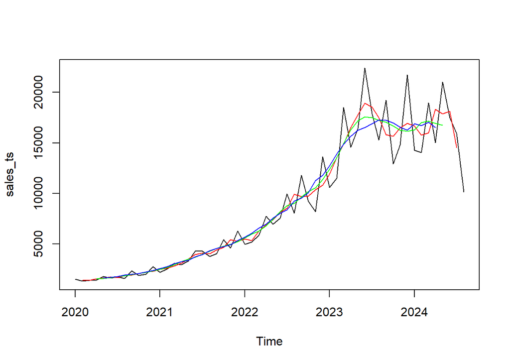

```r
ma_forecast_1 = ma(sales_ts,order=3)
ma_forecast_2 = ma(sales_ts,order=6)
ma_forecast_3 = ma(sales_ts,order=9)

plot(sales_ts)
lines(ma_forecast_1, col="red")
lines(ma_forecast_2, col="green")
lines(ma_forecast_3, col="blue")
```

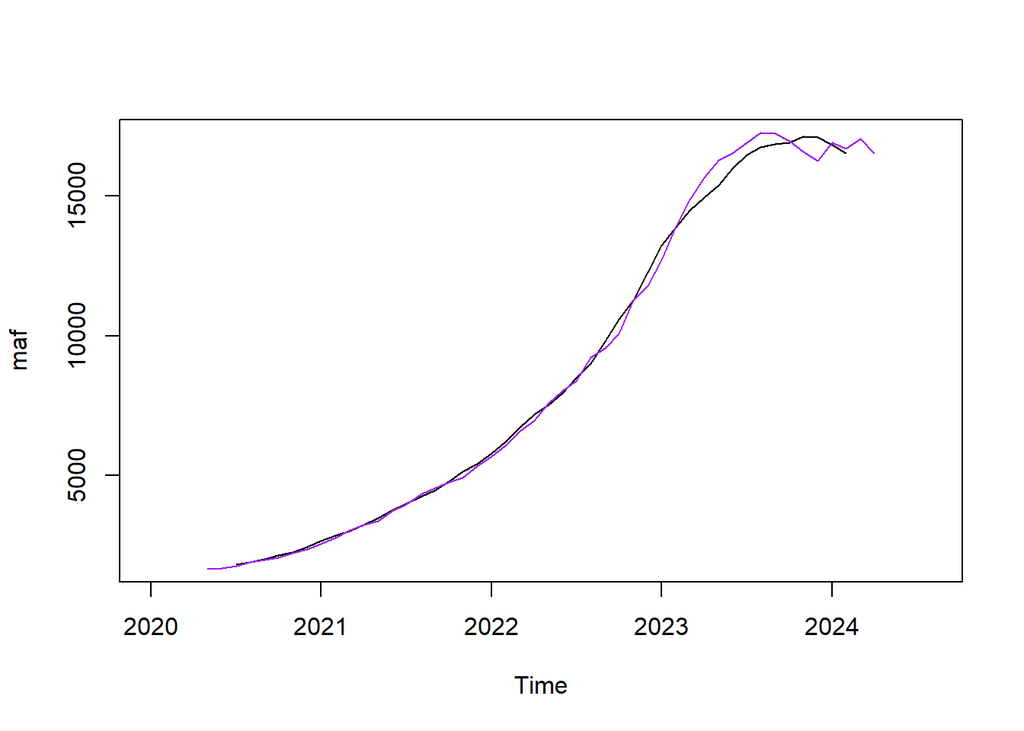

```r
maf <- ma(sales_ts,12)
plot(maf)
lines(ma_forecast_3, col="purple")
```

• What are your observations of the plot as the moving average order goes up?

Smoother Trends: As the moving average order goes up, the line becomes smoother. Higher orders (like 9) are more effective in showing the long-term trend without being influenced by short-term variations.

Lag Effect: With higher orders, there’s more lag in the moving average line, meaning it takes longer to respond to recent changes. This can make higher-order moving averages less responsive to sudden shifts in the data.

Ideal for Long-Term Trends: Higher-order moving averages are ideal for identifying the general direction over time, while lower-order moving averages capture more short-term patterns.

In short, higher moving average orders provide a clearer picture of the long-term trend, while lower orders are better for understanding short-term variations. For stable trend forecasting, order 9 appears to work well for this dataset.

#####Simple Smoothing • Perform a simple smoothing forecast for the next 12 months for the time series.

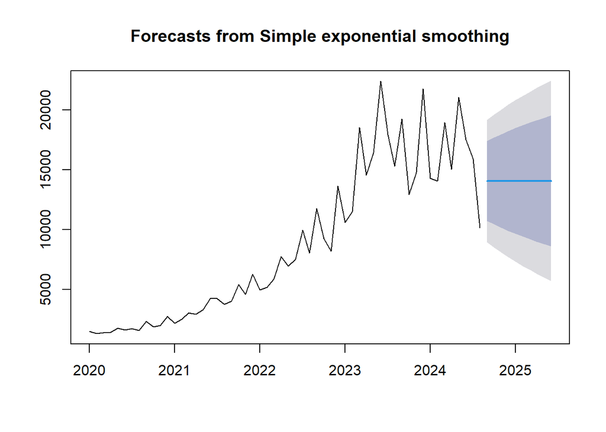

```r
ses_forecast <- ses(sales_ts)
plot(ses_forecast)
```

```r
summary(ses_forecast)
```

```
##
## Forecast method: Simple exponential smoothing
##
## Model Information:
## Simple exponential smoothing
##
## Call:
## ses(y = sales_ts)
##
##   Smoothing parameters:
##     alpha = 0.4319
##
##   Initial states:
##     l = 1472.029
##
##   sigma:  2603.101
##
##      AIC     AICc      BIC
## 1110.202 1110.664 1116.279
##
## Error measures:
##                    ME     RMSE      MAE      MPE     MAPE      MASE       ACF1
## Training set 521.0807 2556.194 1608.255 5.757111 15.49006 0.3569223 -0.1451411
##
## Forecasts:
##          Point Forecast     Lo 80    Hi 80    Lo 95    Hi 95
## Sep 2024       14075.16 10739.153 17411.17 8973.177 19177.14
## Oct 2024       14075.16 10441.301 17709.02 8517.652 19632.67
## Nov 2024       14075.16 10166.078 17984.24 8096.735 20053.59
## Dec 2024       14075.16  9908.998 18241.32 7703.564 20446.76
## Jan 2025       14075.16  9666.884 18483.44 7333.284 20817.04
## Feb 2025       14075.16  9437.393 18712.93 6982.307 21168.01
## Mar 2025       14075.16  9218.734 18931.59 6647.897 21502.42
## Apr 2025       14075.16  9009.505 19140.82 6327.909 21822.41
## May 2025       14075.16  8808.582 19341.74 6020.623 22129.70
## Jun 2025       14075.16  8615.047 19535.27 5724.637 22425.68
```

```r
attributes(ses_forecast)
```

```
## $names
##  [1] "model"     "mean"      "level"     "x"         "upper"     "lower"
##  [7] "fitted"    "method"    "series"    "residuals"
##
## $class
## [1] "forecast"
```

```r
#accuracy
accuracy(ses_forecast)
```

```
##                    ME     RMSE      MAE      MPE     MAPE      MASE       ACF1
## Training set 521.0807 2556.194 1608.255 5.757111 15.49006 0.3569223 -0.1451411
```

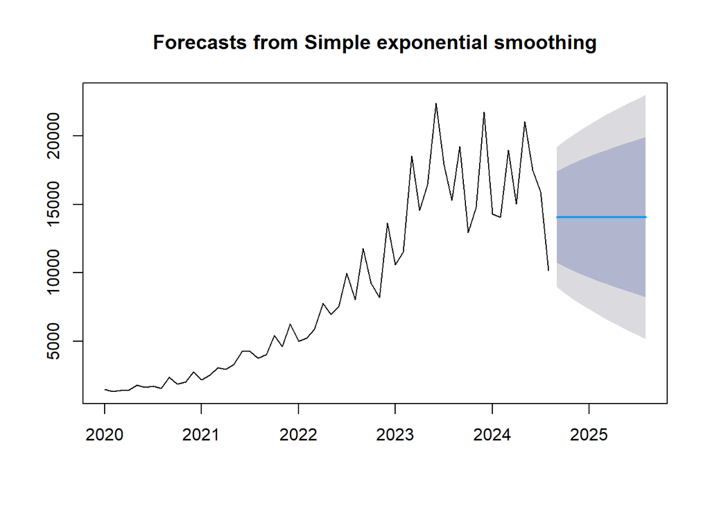

```r
ses_forecast1 <- ses(sales_ts,12)
plot(ses_forecast1)
```

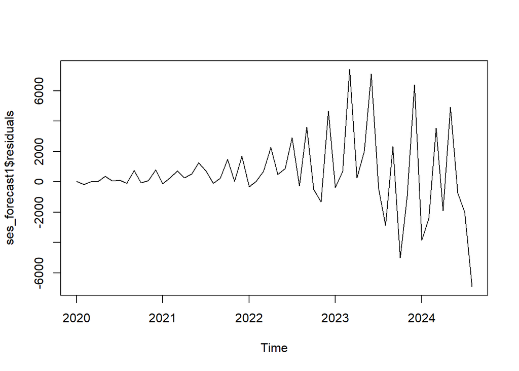

```r
plot(ses_forecast1$residuals)
```

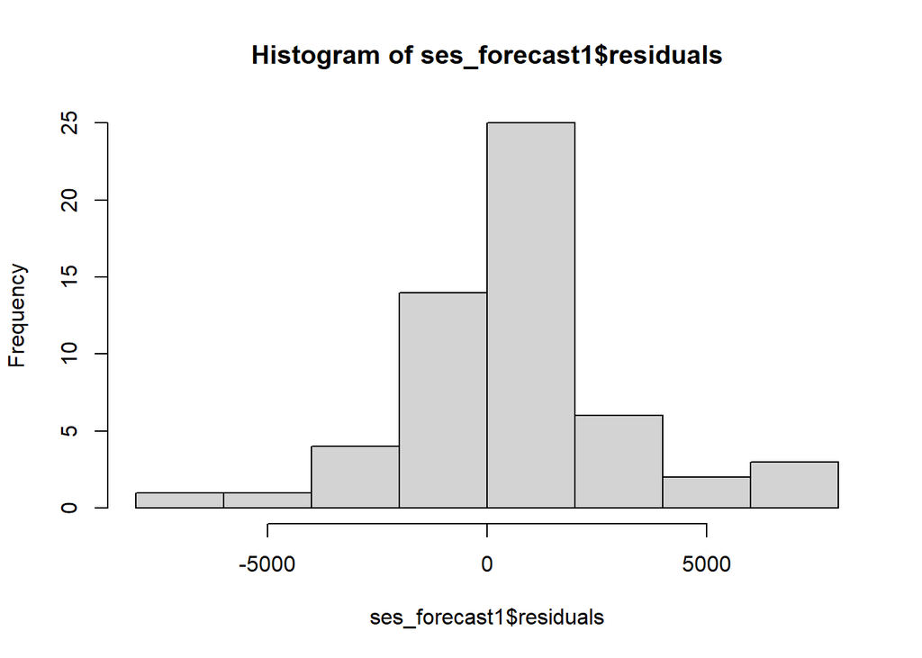

```r
hist(ses_forecast1$residuals)
```

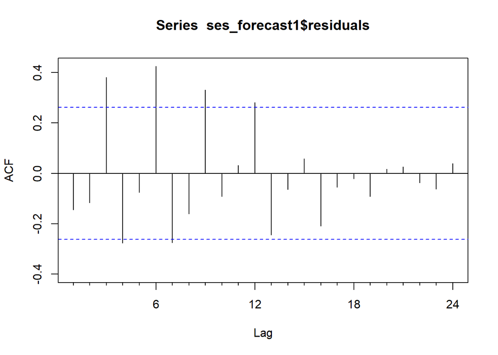

```r
Acf(ses_forecast1$residuals)
```

```r
forecast(ses_forecast1)
```

```
##          Point Forecast     Lo 80    Hi 80    Lo 95    Hi 95
## Sep 2024       14075.16 10739.153 17411.17 8973.177 19177.14
## Oct 2024       14075.16 10441.301 17709.02 8517.652 19632.67
## Nov 2024       14075.16 10166.078 17984.24 8096.735 20053.59
## Dec 2024       14075.16  9908.998 18241.32 7703.564 20446.76
## Jan 2025       14075.16  9666.884 18483.44 7333.284 20817.04
## Feb 2025       14075.16  9437.393 18712.93 6982.307 21168.01
## Mar 2025       14075.16  9218.734 18931.59 6647.897 21502.42
## Apr 2025       14075.16  9009.505 19140.82 6327.909 21822.41
## May 2025       14075.16  8808.582 19341.74 6020.623 22129.70
## Jun 2025       14075.16  8615.047 19535.27 5724.637 22425.68
## Jul 2025       14075.16  8428.141 19722.18 5438.789 22711.53
## Aug 2025       14075.16  8247.226 19903.09 5162.104 22988.22
```

o What is the value of alpha? What does that value signify? The alpha value is 0.4319. Here, an alpha of 0.4319 means the model moderately weights recent data but still considers past data. Higher alpha values would make the model more responsive to recent changes.

o What is the value of the initial state?  
The initial state is 1472.029. This is the starting level that the model uses at the beginning of the forecast period, setting a baseline for subsequent smoothing.

o What is the value of sigma? What does the sigma signify? Sigma is 2603.101, which represents the standard deviation of the model’s residuals. In simpler terms, sigma gives an idea of how much variability or “error” there is in the model’s predictions. A smaller sigma would indicate that the model predictions are closer to the actual data.

• Perform Residual Analysis for this technique.  
o Do a plot of residuals. What does the plot indicate? The residual plot shows the leftover variation after accounting for the trend. Ideally, these should hover around zero with no clear pattern, indicating that the model fits the data well. Any pattern here might mean the model could be missing some information.

o Do a Histogram plot of residuals. What does the plot indicate? The histogram helps check if residuals are centered around zero and normally distributed. If it shows a bell shape centered at zero, that’s a good sign of random error in the model.

o Do an ACF plot of the residuals? What does this plot indicate? The ACF plot shows if there’s any autocorrelation in residuals. Ideally, residuals should be uncorrelated (close to zero). If there’s significant autocorrelation, the model might have missed capturing some patterns in the data.

• Print the five measures of accuracy for this forecasting technique ME RMSE MAE MPE MAPE MASE  
Training set 521.0807 2556.194 1608.255 5.757111 15.49006 0.3569223

• Forecast  
o Time series value for next year. Show table and plot The forecast for the next 12 months predicts a constant sales value of around 14,075.16 each month, with confidence intervals indicating a possible range for each prediction. The confidence intervals widen over time, reflecting increasing uncertainty as we look further into the future.

• Summarize this forecasting technique

o How good is the accuracy? The model’s accuracy is decent, as indicated by reasonable error measures (RMSE, MAE, etc.). The errors are not excessively large, so the model is fairly reliable for short-term forecasting.

o What does it predict the time series value will be in one year? The model forecasts a stable value of 14,075.16 per month for the next year, showing a lack of strong growth or decline trends.

#####Holt-Winters

Perform Holt-Winters forecast for the next 12 months for the time series.

```r
hq <- hw(sales_ts, seasonal = "additive")
plot(hq)

summary(hq)
```

[output not shown]

```
##
## Forecast method: Holt-Winters' additive method
##
## Model Information:
## Holt-Winters' additive method
##
## Call:
## hw(y = sales_ts, seasonal = "additive")
##
##   Smoothing parameters:
##     alpha = 0.3176
##     beta  = 0.0862
##     gamma = 1e-04
##
##   Initial states:
##     l = 818.4249
##     b = 343.2258
##     s = 1774.076 -1565.1 -1259.728 1059.152 -814.7662 753.5157
##            2154.785 120.2898 -57.6465 1068.374 -1562.394 -1670.559
##
##   sigma:  2428.542
##
##      AIC     AICc      BIC
## 1113.622 1129.728 1148.053
##
## Error measures:
##                     ME     RMSE      MAE       MPE     MAPE      MASE
## Training set -210.3775 2052.493 1661.449 -3.401198 33.49673 0.3687275
##                     ACF1
## Training set -0.02495954
##
## Forecasts:
##          Point Forecast       Lo 80    Hi 80       Lo 95    Hi 95
## Sep 2024     14915.4527  11803.1507 18027.75  10155.5976 19675.31
## Oct 2024     11924.6419   8568.2064 15281.08   6791.4168 17057.87
## Nov 2024     10947.3453   7260.7678 14633.92   5309.2115 16585.48
## Dec 2024     13614.6008   9515.1067 17714.09   7344.9656 19884.24
## Jan 2025      9498.2305   4909.7127 14086.75   2480.6981 16515.76
## Feb 2025      8934.2552   3788.3217 14080.19   1064.2291 16804.28
## Mar 2025     10892.9022   5128.5202 16657.28   2077.0406 19708.76
## Apr 2025      9094.7722   2657.3234 15532.22   -750.4562 18940.00
## May 2025      8601.4220   1441.6443 15761.20  -2348.5131 19551.36
## Jun 2025      9963.0717   2036.0955 17890.05  -2160.1923 22086.34
## Jul 2025      7890.2746   -845.1816 16625.73  -5469.4528 21250.00
## Aug 2025      5649.6904  -3932.5846 15231.97  -9005.1345 20304.52
## Sep 2025      6852.1971  -3612.9262 17317.32  -9152.8279 22857.22
## Oct 2025      3861.3863  -7520.3201 15243.09 -13545.4315 21268.20
## Nov 2025      2884.0897  -9446.3507 15214.53 -15973.6915 21741.87
## Dec 2025      5551.3452  -7758.5086 18861.20 -14804.3196 25907.01
## Jan 2026      1434.9749 -12883.6991 15753.65 -20463.5473 23333.50
## Feb 2026       870.9996 -14484.7896 16226.79 -22613.6533 24355.65
## Mar 2026      2829.6466 -13590.5712 19249.86 -22282.9095 27942.20
## Apr 2026      1031.5167 -16479.5699 18542.60 -25749.3792 27812.41
## May 2026       538.1664 -18089.4447 19165.78 -27950.3064 29026.64
## Jun 2026      1899.8161 -17869.2667 21668.90 -28334.3869 32134.02
## Jul 2026      -172.9810 -21107.8371 20761.88 -32190.0805 31844.12
## Aug 2026     -2413.5652 -24537.9059 19710.78 -36249.8244 31422.69
```

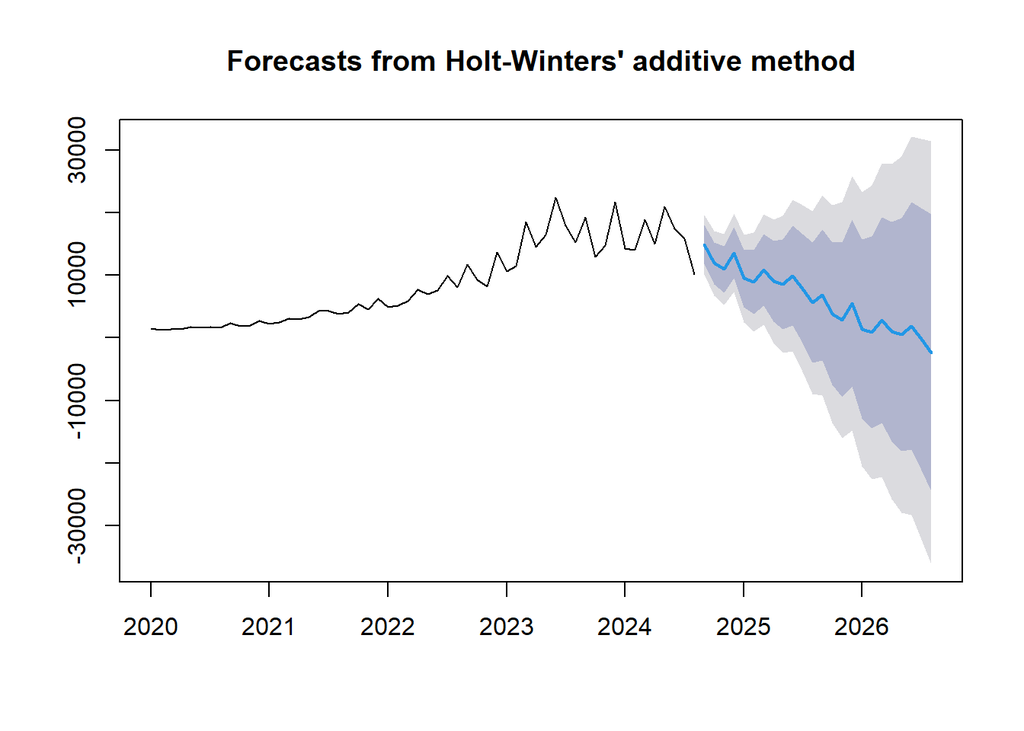

```r
hq1 <- hw(sales_ts,12)
plot(hq)
```

```r
print(hq)
```

```
##          Point Forecast       Lo 80    Hi 80       Lo 95    Hi 95
## Sep 2024     14915.4527  11803.1507 18027.75  10155.5976 19675.31
## Oct 2024     11924.6419   8568.2064 15281.08   6791.4168 17057.87
## Nov 2024     10947.3453   7260.7678 14633.92   5309.2115 16585.48
## Dec 2024     13614.6008   9515.1067 17714.09   7344.9656 19884.24
## Jan 2025      9498.2305   4909.7127 14086.75   2480.6981 16515.76
## Feb 2025      8934.2552   3788.3217 14080.19   1064.2291 16804.28
## Mar 2025     10892.9022   5128.5202 16657.28   2077.0406 19708.76
## Apr 2025      9094.7722   2657.3234 15532.22   -750.4562 18940.00
## May 2025      8601.4220   1441.6443 15761.20  -2348.5131 19551.36
## Jun 2025      9963.0717   2036.0955 17890.05  -2160.1923 22086.34
## Jul 2025      7890.2746   -845.1816 16625.73  -5469.4528 21250.00
## Aug 2025      5649.6904  -3932.5846 15231.97  -9005.1345 20304.52
## Sep 2025      6852.1971  -3612.9262 17317.32  -9152.8279 22857.22
## Oct 2025      3861.3863  -7520.3201 15243.09 -13545.4315 21268.20
## Nov 2025      2884.0897  -9446.3507 15214.53 -15973.6915 21741.87
## Dec 2025      5551.3452  -7758.5086 18861.20 -14804.3196 25907.01
## Jan 2026      1434.9749 -12883.6991 15753.65 -20463.5473 23333.50
## Feb 2026       870.9996 -14484.7896 16226.79 -22613.6533 24355.65
## Mar 2026      2829.6466 -13590.5712 19249.86 -22282.9095 27942.20
## Apr 2026      1031.5167 -16479.5699 18542.60 -25749.3792 27812.41
## May 2026       538.1664 -18089.4447 19165.78 -27950.3064 29026.64
## Jun 2026      1899.8161 -17869.2667 21668.90 -28334.3869 32134.02
## Jul 2026      -172.9810 -21107.8371 20761.88 -32190.0805 31844.12
## Aug 2026     -2413.5652 -24537.9059 19710.78 -36249.8244 31422.69
```

```r
accuracy(hq1)
```

```
##                     ME     RMSE      MAE       MPE     MAPE      MASE
## Training set -210.3775 2052.493 1661.449 -3.401198 33.49673 0.3687275
##                     ACF1
## Training set -0.02495954
```

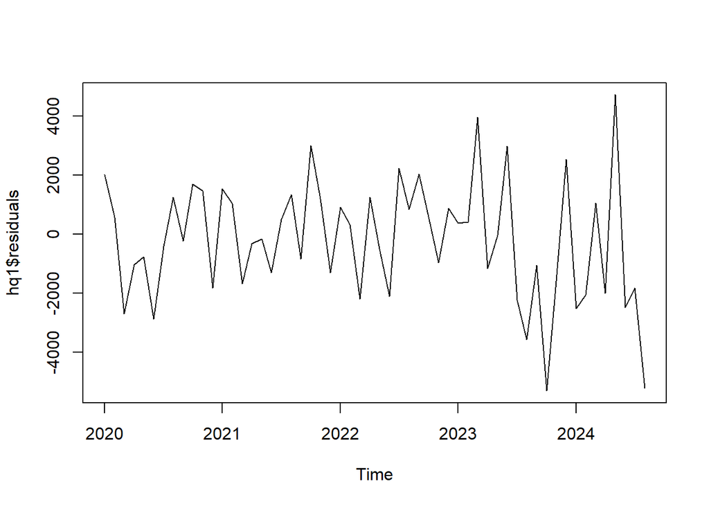

```r
plot(hq1$residuals)
```

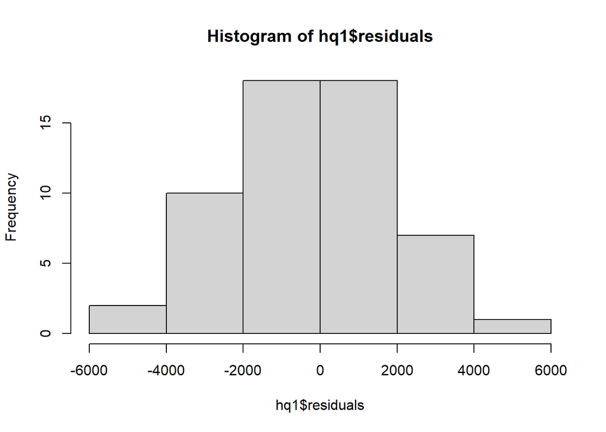

```r
hist(hq1$residuals)
```

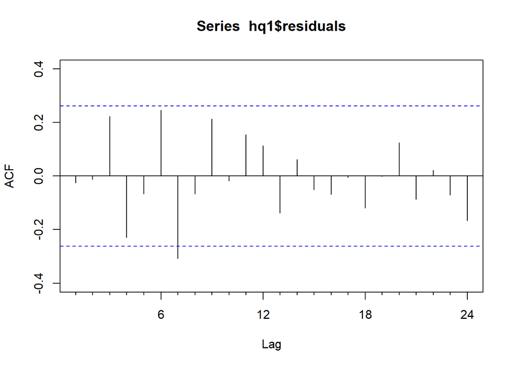

```r
Acf(hq1$residuals)
```

```r
forecast(hq1)
```

```
##          Point Forecast      Lo 80    Hi 80      Lo 95    Hi 95
## Sep 2024      14915.453 11803.1507 18027.75 10155.5976 19675.31
## Oct 2024      11924.642  8568.2064 15281.08  6791.4168 17057.87
## Nov 2024      10947.345  7260.7678 14633.92  5309.2115 16585.48
## Dec 2024      13614.601  9515.1067 17714.09  7344.9656 19884.24
## Jan 2025       9498.231  4909.7127 14086.75  2480.6981 16515.76
## Feb 2025       8934.255  3788.3217 14080.19  1064.2291 16804.28
## Mar 2025      10892.902  5128.5202 16657.28  2077.0406 19708.76
## Apr 2025       9094.772  2657.3234 15532.22  -750.4562 18940.00
## May 2025       8601.422  1441.6443 15761.20 -2348.5131 19551.36
## Jun 2025       9963.072  2036.0955 17890.05 -2160.1923 22086.34
## Jul 2025       7890.275  -845.1816 16625.73 -5469.4528 21250.00
## Aug 2025       5649.690 -3932.5846 15231.97 -9005.1345 20304.52
```

o What is the value of alpha? What does that value signify?  
Alpha is 0.3176. This value signifies the smoothing parameter for the level of the series, indicating how much weight is given to recent observations. A lower alpha means the forecast is less reactive to recent changes.

o What is the value of beta? What does that value signify? Beta is 0.0862. This value represents the trend smoothing parameter, controlling how much emphasis is placed on the trend component. A lower beta suggests a more stable trend.

o What is the value of gamma? What does that value signify? Gamma is 1e-04 . This value controls the seasonality component’s smoothing. A very low gamma means seasonality is kept relatively stable without reacting strongly to new data.

o What is the value of sigma? What does the sigma signify? Sigma is 2428.54, representing the estimated standard deviation of the residuals. It provides an idea of the average deviation of the observed values from the fitted values.

• Perform Residual Analysis for this technique. o Do a plot of residuals. What does the plot indicate? The residuals plot shows fluctuations around zero, indicating the model is capturing the main trends, but some variations are not explained by the model.

o Do a Histogram plot of residuals. What does the plot indicate? The histogram shows that residuals are roughly centered around zero, though not perfectly symmetrical, which suggests minor deviations from normality.

• Print the five measures of accuracy for this forecasting technique ME RMSE MAE MPE MAPE MASE  
Training set -210.3775 2052.493 1661.449 -3.401198 33.49673 0.3687275

• Forecast  
o Time series value for next year. Show table and plot The forecast table and plot show the expected values for the next year, with a gradual decreasing trend and wider prediction intervals, reflecting growing uncertainty over time.

• Summarize this forecasting technique o How good is the accuracy? The accuracy is reasonable, but some deviations in the residuals indicate that improvements could be made, possibly by trying a multiplicative model if seasonality impacts vary with level.

o Other observation The model captures the seasonal and trend components well, but as time progresses, uncertainty increases, as shown by the widening intervals. This suggests that external factors or a different seasonality handling might improve future forecasts.

####Accuracy Summary Show a table of all the forecast methods above with their accuracy measures.

```r
# Define different forecast methods
naive_forecast <- naive(sales_ts, h = 12)
ses_forecast <- ses(sales_ts, h = 12)
holt_forecast <- holt(sales_ts, h = 12)
hw_forecast <- hw(sales_ts, seasonal = "additive", h = 12)
hw_multiplicative_forecast <- hw(sales_ts, seasonal = "multiplicative", h = 12)

# Calculate accuracy for each method
naive_accuracy <- accuracy(naive_forecast)
ses_accuracy <- accuracy(ses_forecast)
holt_accuracy <- accuracy(holt_forecast)
hw_add_accuracy <- accuracy(hw_forecast)
hw_mult_accuracy <- accuracy(hw_multiplicative_forecast)

# Combine accuracy measures into a table
accuracy_table <- rbind(
  Naive = naive_accuracy,
  SES = ses_accuracy,
  Holt = holt_accuracy,
  `Holt-Winters Additive` = hw_add_accuracy,
  `Holt-Winters Multiplicative` = hw_mult_accuracy
)

# Display the accuracy table
print("Accuracy Measures for Different Forecasting Methods:")
```

```
## [1] "Accuracy Measures for Different Forecasting Methods:"
```

```r
print(accuracy_table)
```

```
##                     ME     RMSE      MAE        MPE     MAPE      MASE
## Training set  157.2750 3029.520 2104.495  0.6371928 20.12969 0.4670533
## Training set  521.0807 2556.194 1608.255  5.7571110 15.49006 0.3569223
## Training set -159.4201 2501.717 1574.267 -1.7001757 15.25767 0.3493792
## Training set -210.3775 2052.493 1661.449 -3.4011985 33.49673 0.3687275
## Training set -159.5536 1213.977  925.318 -2.8329232 14.94541 0.2053571
##                      ACF1
## Training set -0.433312005
## Training set -0.145141109
## Training set -0.017018423
## Training set -0.024959542
## Training set -0.001683716
```

```r
# Determine the best and worst forecast method for each accuracy measure
best_methods <- apply(accuracy_table, 2, function(x) rownames(accuracy_table)[which.min(x)])
worst_methods <- apply(accuracy_table, 2, function(x) rownames(accuracy_table)[which.max(x)])

# Combine best and worst methods into a summary table
summary_table <- data.frame(
  Measure = colnames(accuracy_table),
  Best_Method = best_methods,
  Worst_Method = worst_methods
)

# Display the summary table of best and worst methods
print("Best and Worst Forecast Methods for Each Accuracy Measure:")
```

```
## [1] "Best and Worst Forecast Methods for Each Accuracy Measure:"
```

```r
print(summary_table)
```

[output not shown]

• Separately define each forecast method and why it is useful. Show the best and worst forecast method for each of the accuracy measures.

Naive Forecast: Uses the last observed value as the forecast for all future values. Useful for highly random data where trends or seasonality do not add predictive power.

Simple Exponential Smoothing (SES): This method smooths data without a trend or seasonality component. It’s useful when the time series is relatively stable.

Holt’s Linear Trend Model: An extension of SES, it accounts for linear trends in the data. Useful when there’s a consistent upward or downward trend.

Holt-Winters Additive Model: Captures both trend and additive seasonality. Suitable for data with linear trends and seasonality that doesn’t vary with the level of the series.

Holt-Winters Multiplicative Model: Similar to the additive model but uses multiplicative seasonality, making it more effective when seasonal variations increase with the level of the time series.

#####Conclusion:

• Summarize your analysis of time series value over the time period. Looking at the time series data over the period, there’s a clear upward trend with seasonal fluctuations. The values increase during certain months and then dip, indicating a seasonal effect. Over time, these peaks and valleys reflect a steady overall growth trend, although recently the values seem to have reached a slight decline

• Based on your analysis and forecast above, do you think the value of the time series will increase, decrease, or stay flat over the next year? How about the next 2 years?

For Next 2 Years: Over the longer term, some models hint at a possible decline. While the trend might not sharply decrease, it does indicate a tapering off rather than continued strong growth.

Holt’s Linear Trend Model: Decent for trending data but lacks the seasonal component that seems important here.

Simple Exponential Smoothing (SES): Works well for stable data without a trend, but this series has both trend and seasonality.

Naive Forecast: Simple and effective for purely random data but not ideal when a trend or seasonality is present.